# CLV simplificado con IA: prioriza clientes por valor futuro

Author

BI Evolution

## Resumen ejecutivo

Este análisis construye un **CLV simplificado con IA**:

$$\text{CLV\_esperado} \approx \underbrace{P(\text{volver en 90 días})}_{\text{Propensity to Return}} \times \underbrace{\text{Ticket esperado}}_{\text{Ticket Predictor}} \times \underbrace{4}_{\text{horizonte 12 meses}}$$

Con este enfoque:

- Estimamos cuánto podría valer cada cliente en **12 meses**.
- Ordenamos la base según **CLV esperado**.
- Comparamos el **ROI** de dos estrategias con la misma capacidad comercial:
  1. 500 llamadas **al azar**.
  2. 500 llamadas a los clientes con **mayor CLV esperado** según IA.

El objetivo es mostrar, en lenguaje de negocio, cómo pasar de modelos sueltos (Propensity to Return, Ticket Predictor) a un **indicador integrado de valor futuro**.

## 1. Datos simulados de clientes

Se simulan **5,000 clientes** con variables típicas:

- `segmento_cliente` (Alta frecuencia / Media / Ocasional)
- `frecuencia_anual` (número de compras en el año)
- `ticket_promedio_historico` (S/.)
- `dias_ultima_compra`
- `canal_favorito` (Tienda / Online / WhatsApp)
- `uso_cupones` (Sí / No)
- `nivel_satisfaccion` (1 a 5)
- `descuento_promedio` (%)
- `num_categorias` (diversidad de productos)
- `volvio_90dias` (Sí / No) – objetivo de Propensity to Return
- `ticket_real_proxima_compra` (S/.) – objetivo del Ticket Predictor

Muestra de clientes y sus variables de comportamiento (simulado)

| id_cliente | segmento_cliente | frecuencia_anual | ticket_promedio_historico | dias_ultima_compra | canal_favorito | uso_cupones | nivel_satisfaccion | descuento_promedio | num_categorias | volvio_90dias | ticket_real_proxima_compra | R_score | F_score | M_score | rfm_score |
| --- | --- | --- | --- | --- | --- | --- | --- | --- | --- | --- | --- | --- | --- | --- | --- |
| 1 | Media | 3 | 142.7 | 27 | Tienda | 0 | 5 | 7.1 | 3 | No | 242.8 | 5 | 2 | 4 | 11 |
| 2 | Alta frecuencia | 17 | 178.0 | 116 | Online | 0 | 5 | 9.7 | 3 | No | 330.4 | 4 | 5 | 5 | 14 |
| 3 | Media | 6 | 210.9 | 100 | Tienda | 0 | 3 | 8.1 | 3 | No | 252.5 | 4 | 3 | 5 | 12 |
| 4 | Alta frecuencia | 7 | 167.3 | 194 | Tienda | 0 | 5 | 2.1 | 5 | Sí | 211.3 | 3 | 4 | 4 | 11 |
| 5 | Alta frecuencia | 10 | 180.4 | 163 | Online | 1 | 3 | 6.9 | 5 | Sí | 216.7 | 3 | 5 | 5 | 13 |
| 6 | Media | 4 | 97.1 | 35 | Tienda | 0 | 3 | 0.3 | 2 | Sí | 161.8 | 5 | 2 | 2 | 9 |

## 2. Dos modelos base: Propensity to Return y Ticket Predictor

Aquí replicamos la lógica de tus proyectos anteriores, pero en un solo flujo:

1. **Propensity to Return** → clasificador (probabilidad de volver en 90 días).
2. **Ticket Predictor** → regresor (monto de la próxima compra).

> **Lectura rápida:**
> - Para **Propensity to Return**, el modelo seleccionado es Regresión logística.
> - Para **Ticket Predictor**, el modelo seleccionado es Regresión lineal.

## 3. CLV simplificado a 12 meses

En el set de prueba, combinamos ambos modelos:

1. Probabilidad de volver en 90 días: $\hat{p}_i$.
2. Ticket esperado de próxima compra: $\hat{T}_i$.

Asumimos un horizonte simplificado de **12 meses ≈ 4 ciclos de 90 días**:

$$\text{CLV\_esperado}_i = \hat{p}_i \times \hat{T}_i \times 4$$

### 3.1. Distribución del CLV esperado por segmento

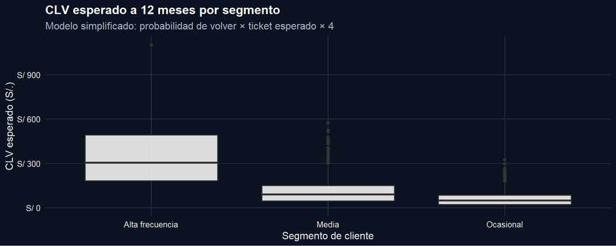

### 3.2. Efecto de RFM sobre el CLV esperado

Aquí usamos el score RFM (suma de R, F y M) para ver cómo se concentra el valor:

- **R_score** alto → clientes recientes.
- **F_score** alto → clientes que compran seguido.
- **M_score** alto → clientes de ticket alto.
- **rfm_score** = R_score + F_score + M_score (de 3 a 15).

Agrupamos el RFM en tres niveles para lectura de negocio.

Relación entre score RFM y CLV esperado a 12 meses

| rfm_nivel | Clientes | CLV promedio (S/.) |
| --- | --- | --- |
| Medio (8–11) | 709 | 136.8 |
| Bajo (3–7) | 494 | 51.7 |
| Alto (12–15) | 296 | 369.4 |

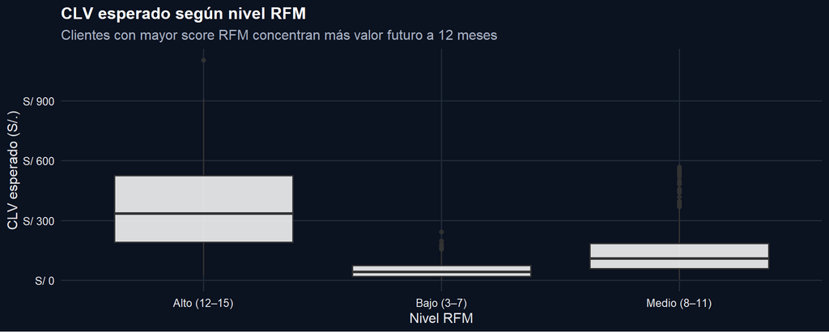

## 4. ROI: 500 llamadas al azar vs. 500 llamadas por CLV

Se comparan dos estrategias con la **misma capacidad comercial**:

- **Sin modelo:** 500 llamadas al azar.
- **Con IA (CLV):** 500 llamadas a los clientes con **mayor CLV esperado**.

### 4.1. Supuestos de negocio y fórmula de ROI

Supuestos:

- Solo se contabiliza la **venta a 12 meses** (usando el CLV real simulado).
- Cada llamada tiene un **costo operativo** (tiempo, canal, etc.) de S/ 4.
- El ROI del escenario se calcula como la suma del margen de cada llamada:

$$\text{ROI} = \sum_{i \in \text{llamados}} \big( \text{retorno\_real\_12m}_i - \text{costo\_llamada} \big)$$

donde:

- $\text{retorno\_real\_12m}_i$ es el valor real simulado a 12 meses del cliente $i$.
- $\text{costo\_llamada}$ es el costo fijo de contactar a cada cliente (S/. 4 en este ejemplo).

Comparación de ROI: al azar vs. priorizar por CLV esperado

| Escenario | ROI estimado (S/.) |
| --- | --- |
| Sin modelo (500 llamadas al azar) | 67102 |
| Con modelo IA (500 mayores CLV esperados) | 165484 |

### 4.2. ¿Cómo se eligen los 500 clientes priorizados?

En la estrategia **Con modelo IA (CLV)**, la lógica es:

1. Para cada cliente del set de prueba se calcula su **CLV_esperado**:

$$\text{CLV\_esperado}_i = \hat{p}_i \times \hat{T}_i \times 4$$

donde:

- $\hat{p}_i$ = probabilidad estimada de volver en 90 días.
- $\hat{T}_i$ = ticket esperado de próxima compra.
- 4 = número de ciclos de 90 días en 12 meses.
2. Se ordenan todos los clientes de **mayor a menor CLV esperado**.
3. Se seleccionan los **500 primeros** de ese ranking.

Y podemos mostrar los **Top 10 clientes priorizados**:

Top 10 clientes priorizados por mayor CLV esperado (según IA)

| id_cliente | segmento_cliente | volvio_90dias | ticket_real | prob_volver_hat | ticket_hat | clv_esperado | real_retorno_12m | R_score | F_score | M_score | rfm_score |
| --- | --- | --- | --- | --- | --- | --- | --- | --- | --- | --- | --- |
| 2890 | Alta frecuencia | Sí | 267.1 | 0.74 | 373.90 | 1102.77 | 1068.4 | 3 | 5 | 5 | 13 |
| 4198 | Alta frecuencia | Sí | 325.8 | 0.76 | 302.05 | 912.70 | 1303.2 | 5 | 5 | 4 | 14 |
| 1170 | Alta frecuencia | Sí | 298.6 | 0.64 | 344.66 | 884.14 | 1194.4 | 3 | 5 | 5 | 13 |
| 3148 | Alta frecuencia | Sí | 365.9 | 0.68 | 324.80 | 882.11 | 1463.6 | 4 | 5 | 5 | 14 |
| 2069 | Alta frecuencia | Sí | 188.4 | 0.78 | 283.19 | 880.00 | 753.6 | 5 | 5 | 4 | 14 |
| 2795 | Alta frecuencia | Sí | 270.2 | 0.79 | 270.74 | 859.68 | 1080.8 | 5 | 5 | 4 | 14 |
| 2405 | Alta frecuencia | No | 471.3 | 0.70 | 303.74 | 852.08 | 0.0 | 5 | 5 | 5 | 15 |
| 4930 | Alta frecuencia | Sí | 289.1 | 0.70 | 302.63 | 842.74 | 1156.4 | 5 | 5 | 5 | 15 |
| 4904 | Alta frecuencia | No | 263.9 | 0.73 | 278.17 | 806.85 | 0.0 | 5 | 5 | 3 | 13 |
| 806 | Alta frecuencia | No | 437.2 | 0.59 | 343.74 | 806.74 | 0.0 | 5 | 5 | 5 | 15 |

### 4.3. Comparativa visual del ROI

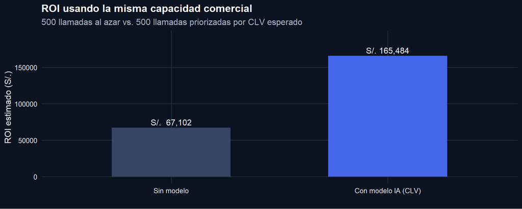